# Correlation and Covariance Review

[Class Web Page](http://gozips.uakron.edu/~nmimoto/477/index.html) – [R resource page](http://gozips.uakron.edu/~nmimoto/R/index.html)

## 1. Covariance

$$\begin{aligned}
\mbox{Cov}(X,Y) &= E\Big[\big(X-E(X)\big)\big(Y-E(Y)\big)\Big] \\\\
&= E[XY] - E(X)E(Y)
\end{aligned}$$

## Correlation

Correlation defined as:
$$\rho = \frac{\mbox{Cov}(X,Y) }{ \sigma_X \sigma_Y}$$

This will ensure $-1 \leq \rho \leq 1$.

Follows from Cauchy-Schwartz inequality,
$$E\big[ \big| (X-\mu_X)(Y-\mu_Y) \big| \big]
\leq \sqrt{ E\big[(X-\mu_X)^2\big] \, E\big[(Y-\mu_Y)^2\big] }$$

### Difference

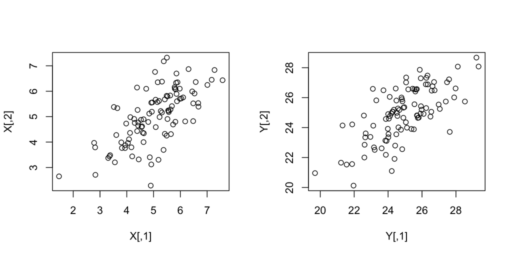

```r
  library(mvtnorm)
  set.seed(363)
  X = rmvnorm(100, c(5,5),   matrix(c(1,.7,.7,1), 2,2))
  Y = rmvnorm(100, c(25,25), matrix(c(3,2.1,2.1,3), 2,2))
  layout(matrix(1:2, 1, 2))
  plot(X)
  plot(Y)
```

```r
  cov(X)
```

```
##           [,1]      [,2]
## [1,] 1.1585022 0.7897293
## [2,] 0.7897293 1.1826087
```

```r
  cov(Y)
```

```
##          [,1]     [,2]
## [1,] 3.124203 2.175931
## [2,] 2.175931 3.129385
```

```r
  cor(X)
```

```
##           [,1]      [,2]
## [1,] 1.0000000 0.6746978
## [2,] 0.6746978 1.0000000
```

```r
  cor(Y)
```

```
##           [,1]      [,2]
## [1,] 1.0000000 0.6958988
## [2,] 0.6958988 1.0000000
```

### Properties of Covariance

- $\mbox{Cov}(X,X) = \mbox{Var}(X)$
- $\mbox{Cov}(X,Y)=\mbox{Cov}(Y,X)$
- If $X,Y,S,T$ are all random variables,
  $$\mbox{Cov}(X+Y,S+T) = \mbox{Cov}(X,S) + \mbox{Cov}(X,T) + \mbox{Cov}(Y,S) + \mbox{Cov}(Y,T)$$
- If $a$ is a constant, $\mbox{Cov}(aX,Y) = a\mbox{Cov}(X,Y)$
- $\mbox{Cov}(a,Y) = 0$
- Example $Var(X+Y)$

### Properties of Correlation

$\rho$ is unitless.
$$\rho = \frac{E\Big[(X-\mu_X)(Y-\mu_Y)\Big]}{ \sigma_X \sigma_Y}$$

$\rho$ is invariant under linear transformation.
$$\mbox{Corr}(aX+b,Y)
= \frac{ \mbox{Cov}(aX+b,Y) }{ \sigma_{aX+b} \, \sigma_Y}
= \frac{ a \mbox{Cov}(X,Y) }{ a \, \sigma_{X} \, \sigma_Y}
=
\mbox{Corr}(X,Y)$$

No correlation does not mean independence.

## 2. Autocorrelation

In the last lecture, we look at Canadian Hare Abundance data, and fond autocorrelation at lag 1.

```r
  acf1 <- acf    # copy the original acf function
  library(TSA)   # load package TSA, which replaces default acf
  acf  <- acf1   # copy back the original

  data(hare)     # load hare data from TSA

  length(hare)
```

```
## [1] 31
```

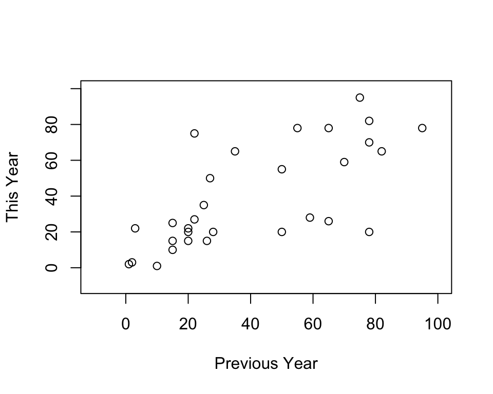

```r
  thisYear <- hare[2:31]
  lastYear <- hare[1:30]

  plot(lastYear, thisYear, ylab="This Year",xlab="Previous Year", xlim=c(-10,100), ylim=c(-10,100))
```

```r
  cor(lastYear, thisYear)    # calculate correlation
```

```
## [1] 0.7025777
```

This prompted us to plot the autocorrelation function (ACF) at various lags.

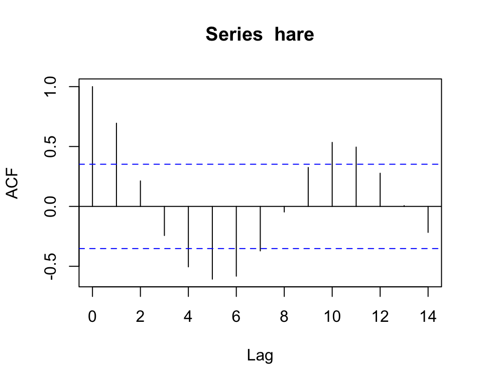

```r
  acf(hare)
```

### 2.1 Formula for ACF

- When you have two vectors,
  $$(X_1, \ldots, X_n), \hspace5mm \mbox{ and } \hspace5mm (Y_1, \ldots, Y_n)$$
  - Formula for **Sample Correlation $r$**
    $$r = \hat \rho = \frac{1}{n-1} \sum_{i=1}^n \frac{(X_i - \bar X)}{S_X}\frac{(Y_i - \bar Y)}{S_Y}$$
    where $S_x$ and $S_Y$ are sample standard deviation of $X$ and $Y$ respectively.
- Given one vector $X_1, \ldots, X_{31}$, Autocorrelation function needs to measure correlation between
  $$\mbox{ This Year:} \hspace5mm (X_2, X_3, X_4, \ldots, X_{31})
  \hspace5mm \mbox{ vs } \hspace5mm
  \mbox{ Last Year:} \hspace5mm (X_1, X_2, X_3, \ldots, X_{30})$$
  - Formula for **Autocovariance Function at Lag 1** is
    $$\hat \gamma(1) = \frac{1}{n} \sum_{i=1}^{n-1} (X_i - \bar X) (X_{i-1} - \bar X) \\$$
  - Formula for **Autocovariance Function at Lag h** is
    $$\hat \gamma(h) = \frac{1}{n} \sum_{i=1}^{n-|h|} (X_i - \bar X) (X_{i-|h|} - \bar X) \\$$

### 2.2 ACVF and ACF

(Autocovariance and Autocorrelation) Given sequence of random variable $\{X_1, \dots, X_n\}$,

- ACVF : AutoCoVariance Function (at lag $h$)
  $$\gamma(h) = \mbox{COV}(X_t, X_{t-h})$$
- ACF : AutoCorrelation Function (at lag $h$)
  $$\rho(h) = \mbox{COR}(X_t, X_{t-h})$$

### 2.3 Cov and ACVF

Sample Covariance
$$\hat \rho = \frac{COV(X_t, Y_t)}{\sqrt{V(X_t) V(Y_t)}}$$

Sample Autocovariance Function
$$\hat \gamma(h) = \frac{1}{n} \sum_{i=1}^{n-|h|} (X_{t} - \bar X) (X_{t+|h|} - \bar X)$$
$$\hat \gamma(0) = V(X_t)$$

ACF and ACVF is related as:
$$\hat \rho(h) = \frac{\hat \gamma(h)}{\hat \gamma(0)}$$
because $\hat \gamma(0)$ is (basically) same as Sample Variance of $X= S^2_X$.

### 2.4 Properties

- ACF and ACVF is symmetric in $h$. (e.g. $\gamma(h) = \gamma(-h)$)
- $\rho(0) = 1$ and $\hat \rho(0) = 1$.
- Don’t plot for $h$ that is too big relative to $n$. ($n \geq 50$ and $h \leq n/4$)

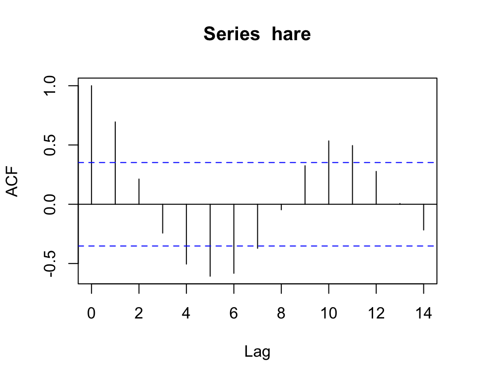

```r
  acf(hare)                      # compute and plot ACF

  Rho.hat <- acf(hare)           # compute ACF and assign to Rho.hat
```

```r
  Rho.hat
```

```
##
## Autocorrelations of series 'hare', by lag
##
##      0      1      2      3      4      5      6      7      8      9     10     11
##  1.000  0.695  0.213 -0.243 -0.505 -0.607 -0.582 -0.371 -0.046  0.325  0.534  0.495
##     12     13     14
##  0.277  0.006 -0.217
```

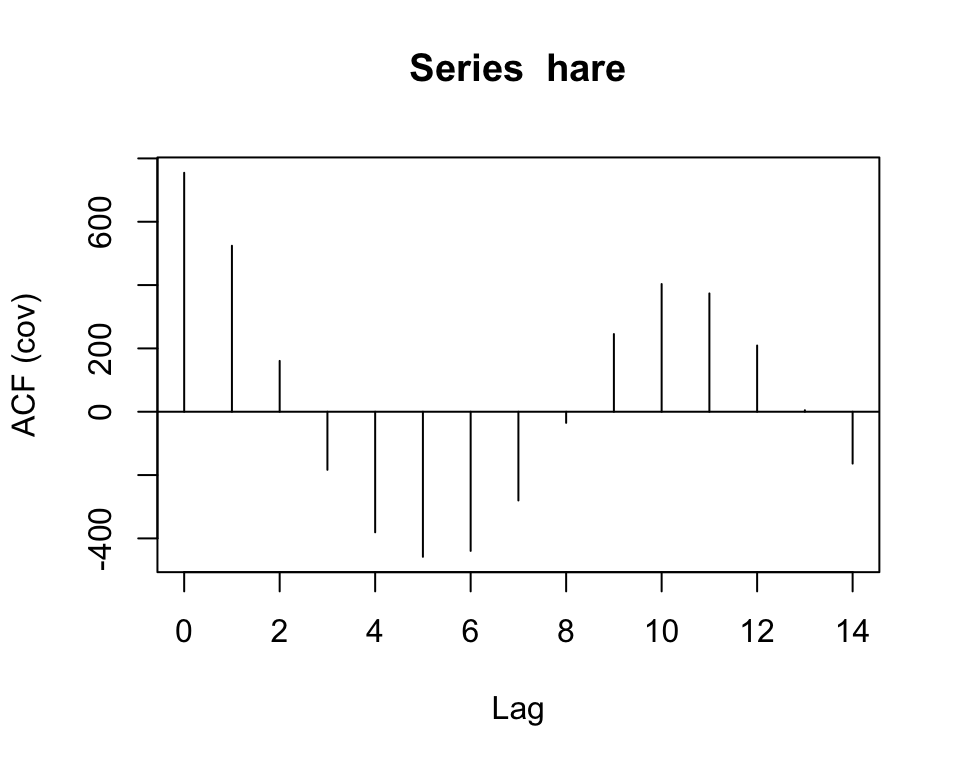

```r
  Rho.hat <- acf(hare, plot=FALSE)   # compute ACF w/o plotting

  acf(hare, type="covariance")   # compute and plot ACVF

  Gam.hat <- acf(hare, type="covariance")   # store numbers from ACVF
```

```r
  Gam.hat
```

```
##
## Autocovariances of series 'hare', by lag
##
##       0       1       2       3       4       5       6       7       8       9      10
##  754.57  524.16  160.51 -183.37 -380.72 -458.11 -439.43 -280.20  -35.07  245.28  403.27
##      11      12      13      14
##  373.61  209.11    4.76 -163.73
```

```r
  Gam.hat[0]
```

```
##
## Autocovariances of series 'hare', by lag
##
##   0
## 755
```

```r
  var(hare)                      # not same as Gam.hat[0]
```

```
## [1] 779.7226
```

```r
  var(hare) * 30 / 31            # same as Gam.hat[0]
```

```
## [1] 754.5702
```

## 3. White Noise

Back to **LArain** exampe

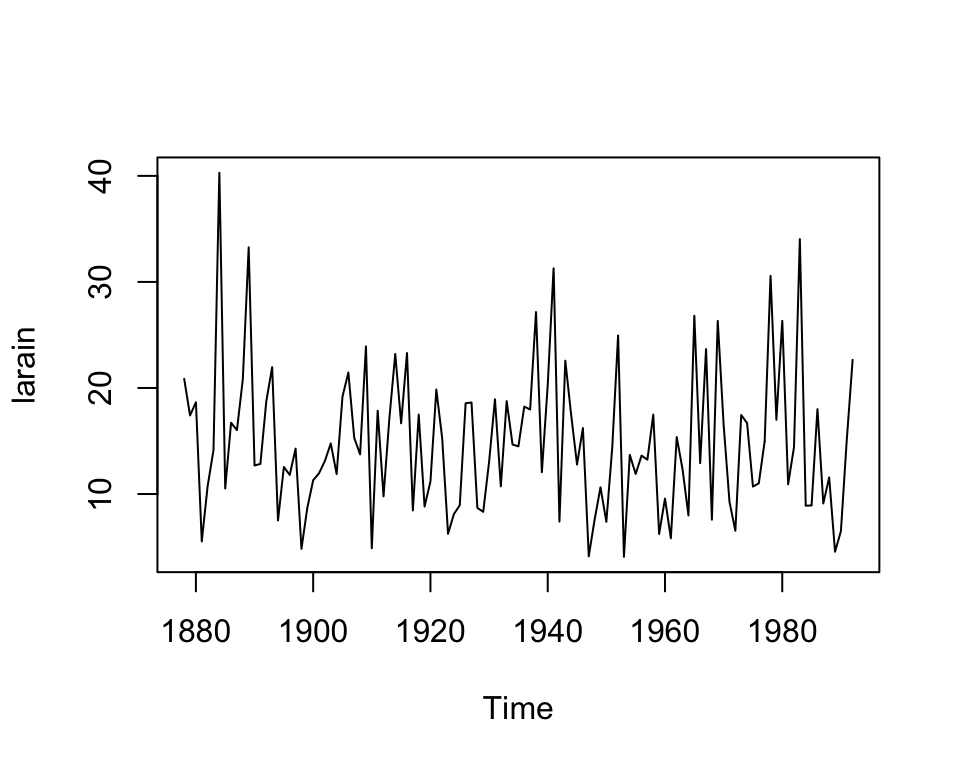

```r
  data(larain)
  plot(larain)
```

```r
  length(larain)     # this is n
```

```
## [1] 115
```

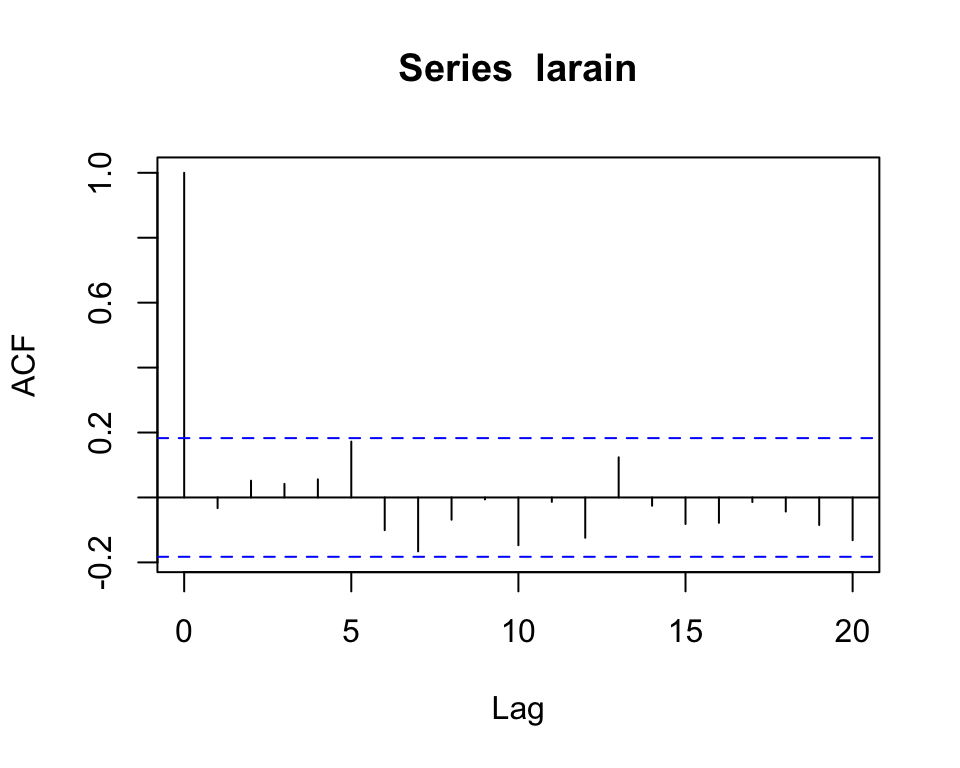

```r
  acf(larain)
```

```r
  1.96/sqrt(115)     # size of the blue line
```

```
## [1] 0.1827709
```

- We deem that all ACF we see in the plot are not significant.
- Annual Rainfall in LA is probably **White Noise**.
- White Noise is a uncorrelated series of any distribution. It may not be identically distributed.
- Uncorrelation is not independence
- White Noise have no autocorrelation, and not limited to normal distribution.